# Wine Data Exploration by Yijian Zong

[figure not shown]

The first plot shows overplotting. After adjustment by adding jitter and changing transparency, we still can see that the data is over-dispersed.

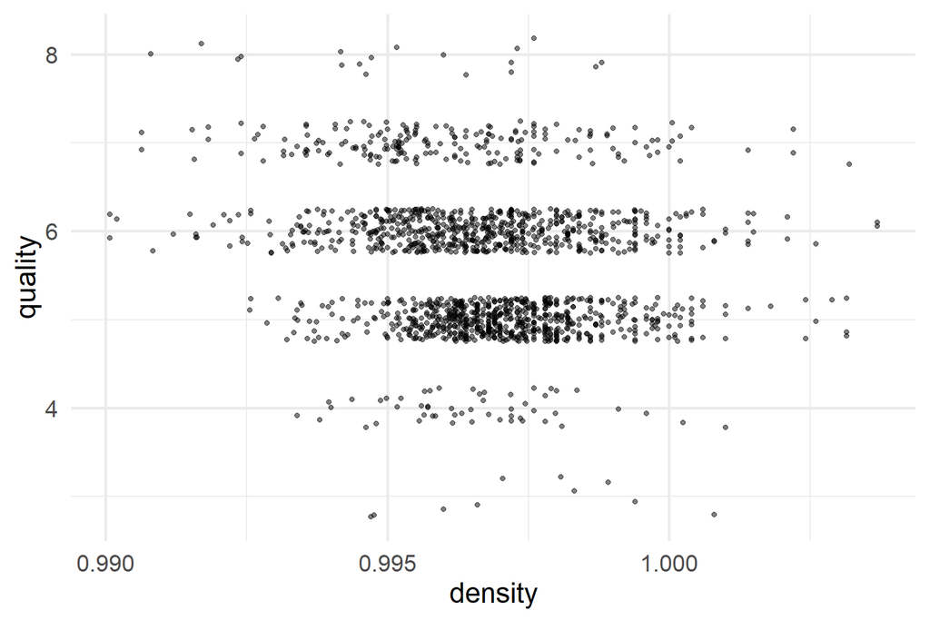

Density distribution is similar to that of alcohol.

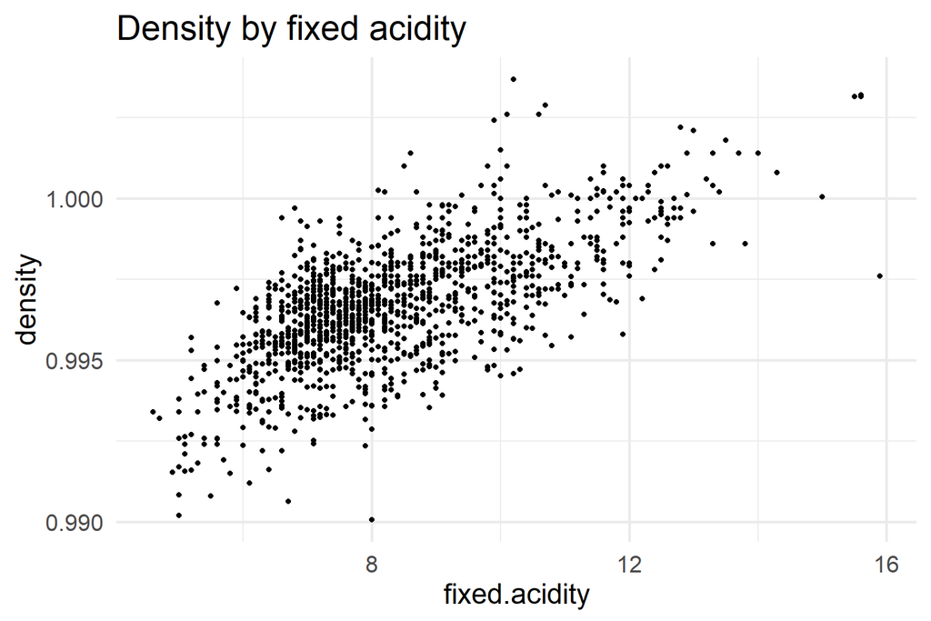

We there is a clear positive relationship between fixed.acidity and density. In fact, the typical concentration of fixed acid in wine is 6000 mg/L, which is quite big, only second to Glycerol.

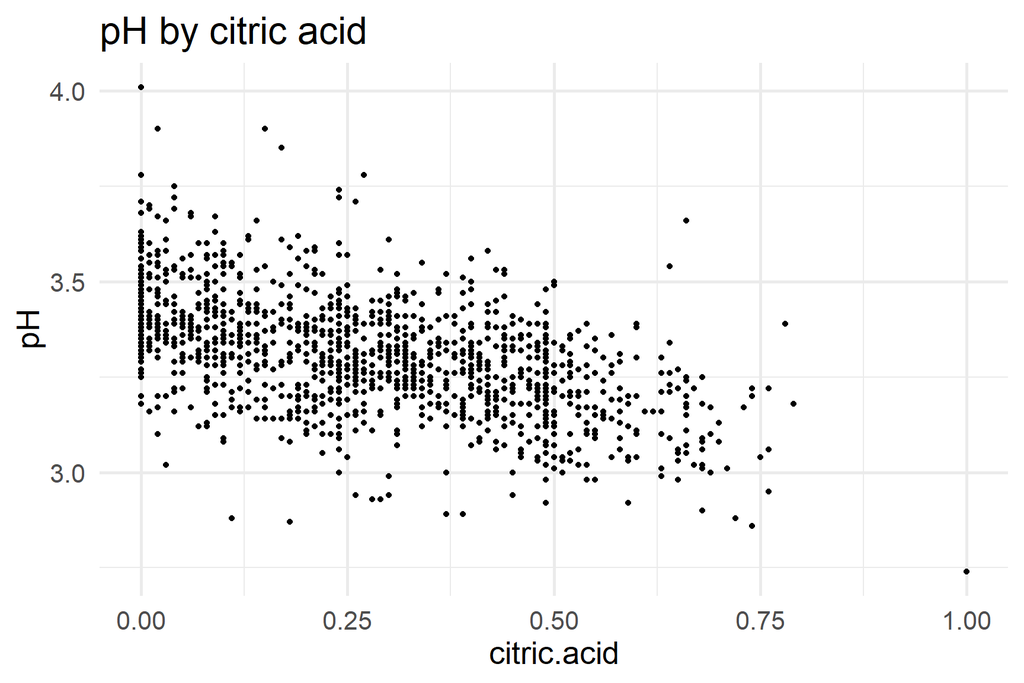

We can see pH is negatively related to citric acid. This no surprise since the higher the acid, the lower the pH.

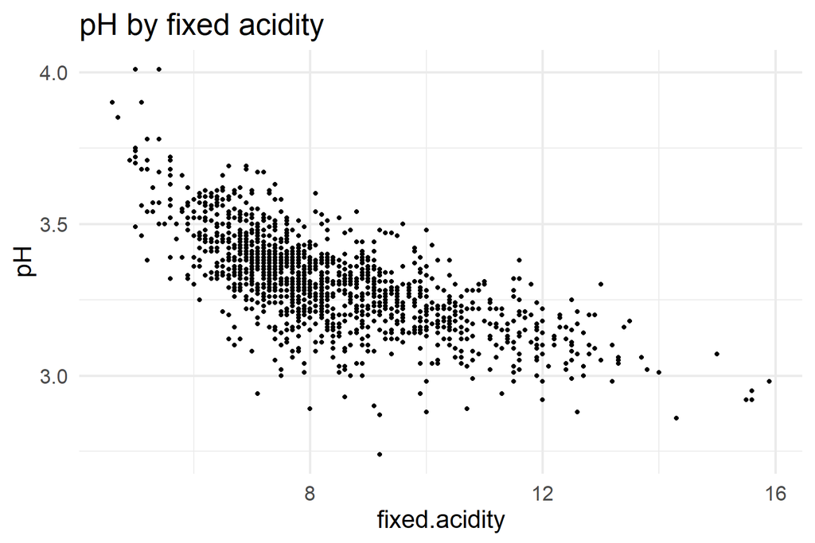

Same trend has been observed in the plot of pH vs fixed acidity.

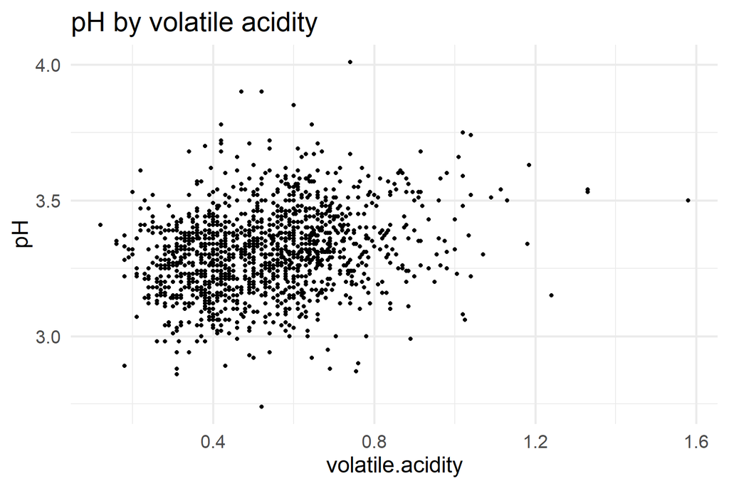

However, the trend is lost when we plot pH vs volatile acidity.  
In general, We see there is a negative strong correlation between citric acid and pH which is not surprising since the more acidic a solution is, the lower pH it has. The same siuation applies to other acid metrics like fixed.acidity. However, volatile acidity doesn’t show such correlation.

```
##
## Call:
## lm(formula = quality ~ alcohol, data = wine)
##
## Residuals:
##     Min      1Q  Median      3Q     Max
## -2.8442 -0.4112 -0.1690  0.5166  2.5888
##
## Coefficients:
##             Estimate Std. Error t value Pr(>|t|)
## (Intercept)  1.87497    0.17471   10.73   <2e-16 ***
## alcohol      0.36084    0.01668   21.64   <2e-16 ***
## ---
## Signif. codes:  0 '***' 0.001 '**' 0.01 '*' 0.05 '.' 0.1 ' ' 1
##
## Residual standard error: 0.7104 on 1597 degrees of freedom
## Multiple R-squared:  0.2267, Adjusted R-squared:  0.2263
## F-statistic: 468.3 on 1 and 1597 DF,  p-value: < 2.2e-16
```

```
##
## Call:
## lm(formula = quality ~ pH + fixed.acidity, data = wine)
##
## Residuals:
##     Min      1Q  Median      3Q     Max
## -2.8612 -0.5994  0.1835  0.4315  2.5214
##
## Coefficients:
##               Estimate Std. Error t value Pr(>|t|)
## (Intercept)    4.14773    0.68512   6.054 1.76e-09 ***
## pH             0.26464    0.17775   1.489    0.137
## fixed.acidity  0.07357    0.01576   4.668 3.30e-06 ***
## ---
## Signif. codes:  0 '***' 0.001 '**' 0.01 '*' 0.05 '.' 0.1 ' ' 1
##
## Residual standard error: 0.8013 on 1596 degrees of freedom
## Multiple R-squared:  0.01675,    Adjusted R-squared:  0.01552
## F-statistic:  13.6 on 2 and 1596 DF,  p-value: 1.394e-06
```

Still, the pH and fixed.acidity don’t explained the quality well.

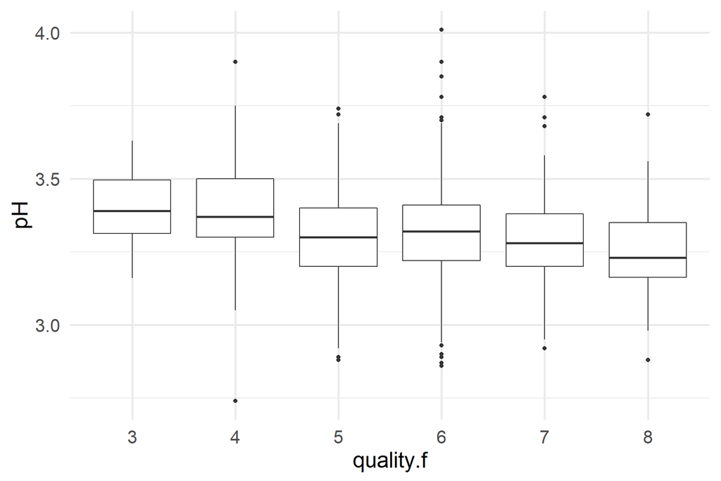

The mean pH look similar across quality groups. However, a wine with higher quality tends to have smaller pH.

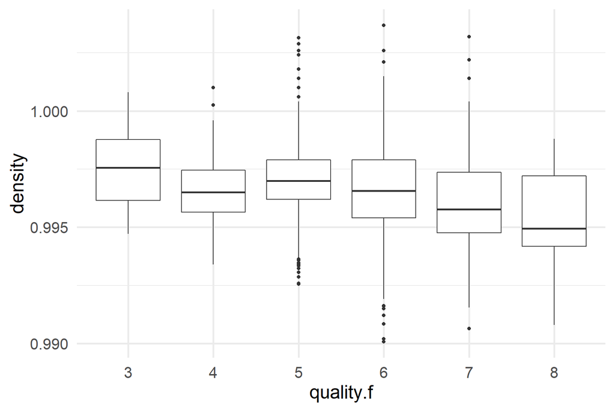

Here we see higher quality tends to have lower density.

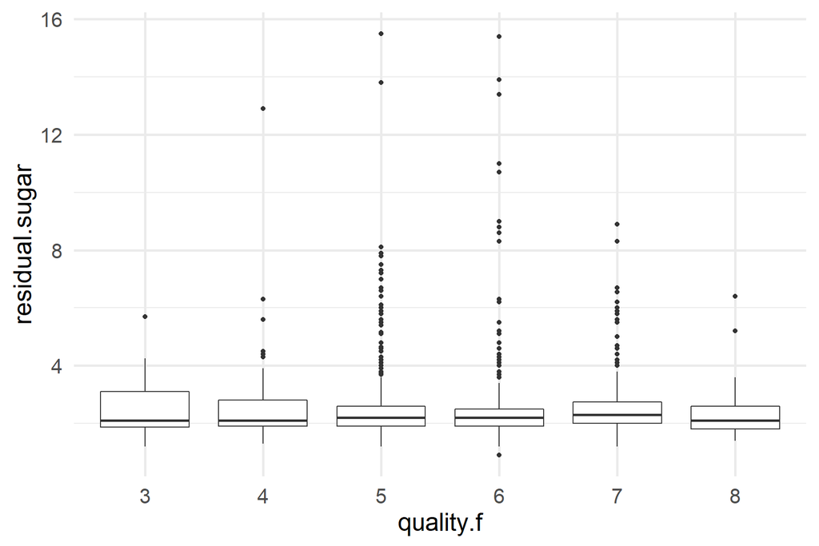

Here we see the medians of residual sugar are very similar across quality groups, yet the middle quality groups(5,6) have many outliers that drives mean higher than median.

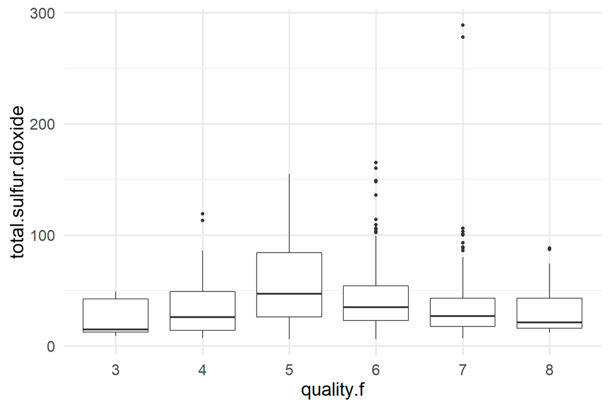

Here we see the middle quality range have higher median total sulfur dioxide.

# Bivariate Analysis

### Talk about some of the relationships you observed in this part of the investigation. How did the feature(s) of interest vary with other features in the dataset?

There are no variables that have strong correlation with win quality. Regardless of quality, the variance in alcohol is high in each level. In the plot of quality vs alcohol, at each quality level the alcohol amount is spread out.

Based on the R^2 value, alcohol can only explain about 22.6%, yet other variable such as pH did a worse job.

Density has a distribution across quality groups similar to alcohol.

### What was the strongest relationship you found?

The strongest relationship is between citric.acid and fixed.acidity.

# Multivariate Plots Section

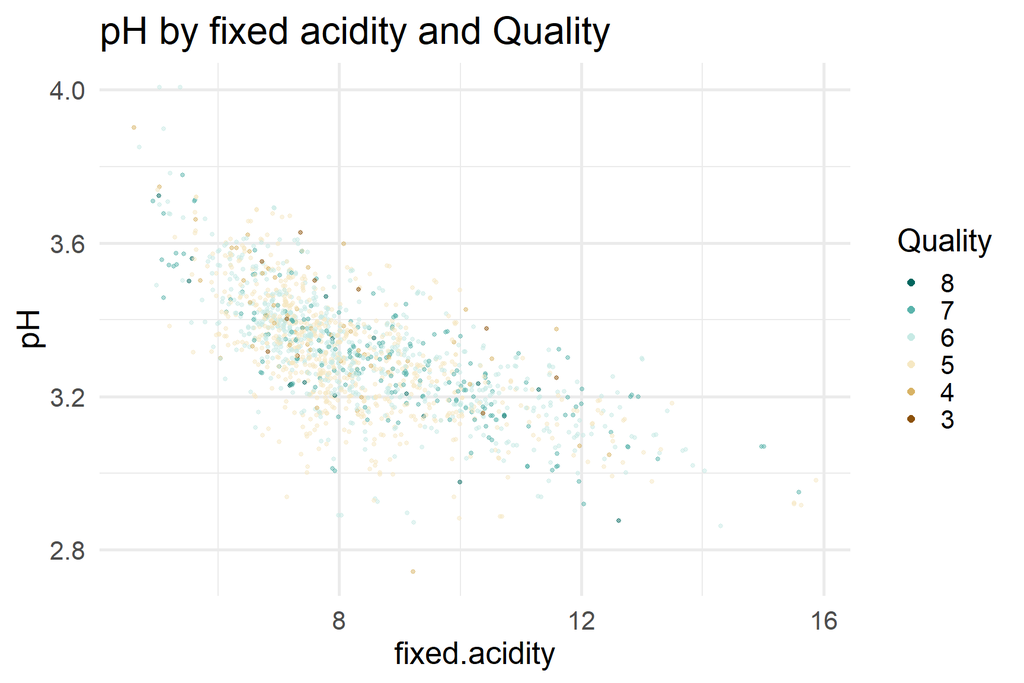

We can see higher quality wine tend to stay close on the linear line.

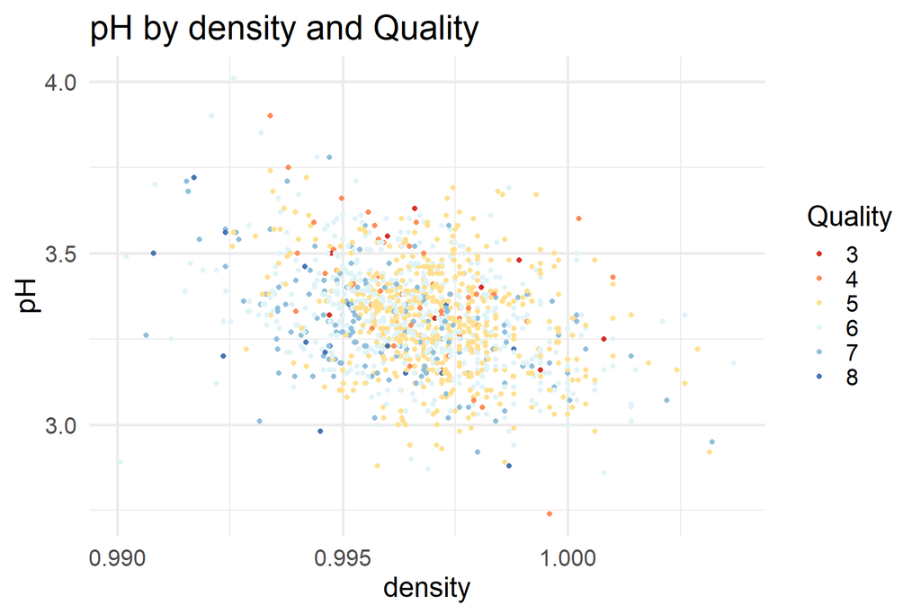

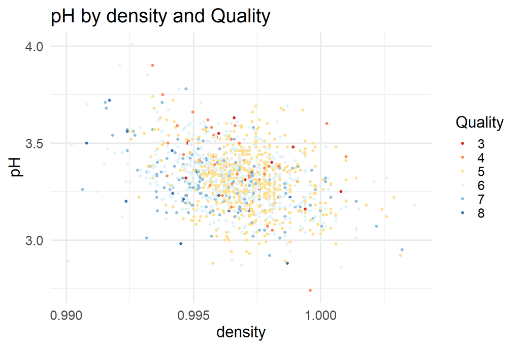

As wee see, most wine cluttered in group with density between 0.995 and 1 and pH between 3.0 and 3.5.

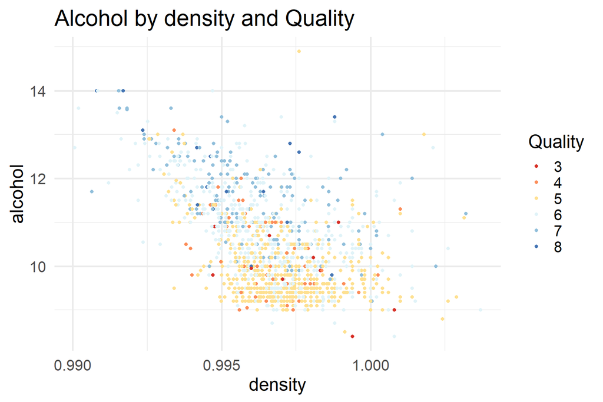

We see lower quality wine tends to fall in section with density between 0.995 and 1.000 and alcohol between 9 and 10.

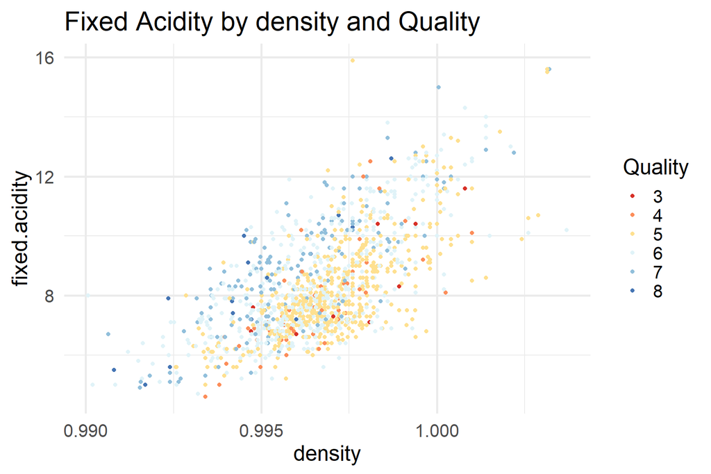

As we see, wine with different are pretty dispersed across the density axis.

```
##
## Calls:
## m1: lm(formula = quality ~ alcohol, data = wine)
## m2: lm(formula = quality ~ alcohol + pH, data = wine)
## m3: lm(formula = quality ~ alcohol + pH + density, data = wine)
## m4: lm(formula = quality ~ alcohol + pH + density + fixed.acidity,
##     data = wine)
## m5: lm(formula = quality ~ alcohol + pH + density + fixed.acidity +
##     citric.acid, data = wine)
##
## ========================================================================================
##                        m1            m2            m3            m4            m5
## ----------------------------------------------------------------------------------------
##   (Intercept)         1.875***      4.426***     -9.593        29.491        34.041*
##                      (0.175)       (0.387)      (11.293)      (17.324)      (17.284)
##   alcohol             0.361***      0.386***      0.397***      0.356***      0.335***
##                      (0.017)       (0.017)       (0.019)       (0.023)       (0.024)
##   pH                               -0.850***     -0.808***     -0.419*       -0.263
##                                    (0.116)       (0.121)       (0.178)       (0.181)
##   density                                        13.811       -26.811       -31.593
##                                                 (11.119)      (17.610)      (17.572)
##   fixed.acidity                                                 0.065**       0.040
##                                                                (0.022)       (0.023)
##   citric.acid                                                                 0.497***
##                                                                              (0.126)
## ----------------------------------------------------------------------------------------
##   R-squared           0.227         0.252         0.253         0.257         0.264
##   adj. R-squared      0.226         0.251         0.251         0.255         0.262
##   sigma               0.710         0.699         0.699         0.697         0.694
##   F                 468.267       268.888       179.834       137.741       114.313
##   p                   0.000         0.000         0.000         0.000         0.000
##   Log-likelihood  -1721.057     -1694.466     -1693.693     -1689.282     -1681.507
##   Deviance          805.870       779.508       778.755       774.470       766.975
##   AIC              3448.114      3396.931      3397.385      3390.563      3377.014
##   BIC              3464.245      3418.440      3424.271      3422.826      3414.654
##   N                1599          1599          1599          1599          1599
## ========================================================================================
```

We made a linear model to predict quality based on the most related features we have. However, none of them explains the variance of quality well.

### From the linear model, we can see as we add more variables, the R^2 don’t change much, which means the model doesn’t explain the variance in quality well.

# Multivariate Analysis

### Talk about some of the relationships you observed in this part of the investigation. Were there features that strengthened each other in terms of

looking at your feature(s) of interest?

- There is no single clear relationship that explains what makes a wine have a good quality. Yet there is a pattern that lower quality wine tends to fall in section with density between 0.995 and 1.000 and alcohol between 9 and 10.
- Through multivariate plot, we can see density and fixed density strengthened each other. Across all quality groups, higher density is related to higher fixed acidity, which makes sense because the more stable acid stays in wine, the more dense it is.

### Were there any interesting or surprising interactions between features?

One interesting interaction is the plot of pH vs density with color of quality since I expected that certain combination of pH and density would contribute to a quality of wine. However, quality is pretty dispersed across the plot.

### OPTIONAL: Did you create any models with your dataset? Discuss the strengths and limitations of your model.

I create a linear model to predict quality. However, the highest R^2 is only 0.264, which means linear model might not be a good metrics for predicting the quality of wine. However, some useful information can be fetched. Among all the features in the model, pH improves the model by the most extent. ——

# Final Plots and Summary

### Plot One

[figure not shown]

### Description One

The distribution of total sulfur dioxide appears to be bimodal on log scale.  
Perhaps, wines are divided into two ranges to sulfur dioxide amount. There is also an gap in the upper range between 5 and 5.5.

### Plot Two

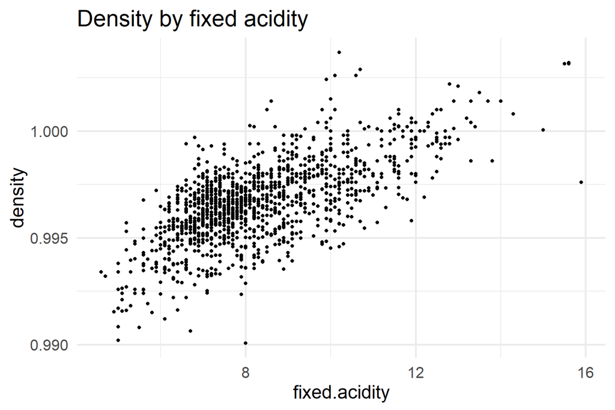

### Description Two

We see that fixed.acidity has a moderate positive relationship between density. This raises interesting questions about what determines the density of a wine. Fixed.acidity might be a good component.

### Plot Three

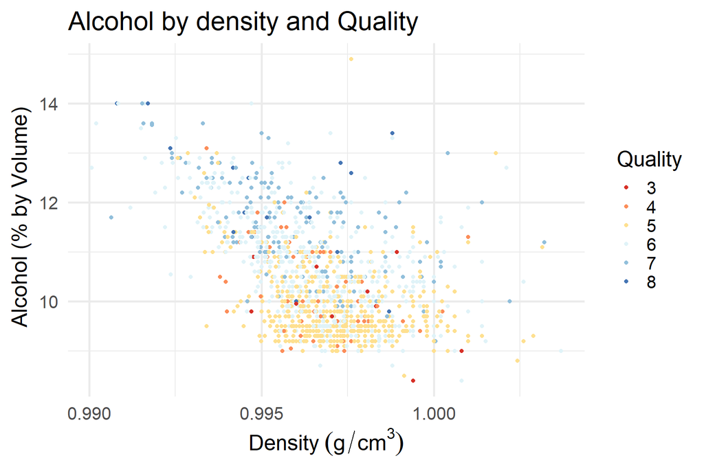

### Description Three

We see lower quality wine tends to fall in section with density between 0.995 and 1.000 and alcohol between 9 and 10. This means low quality wine could be associated with high density and low alcohol. This points to an interesting speculation that high density might contain other unnecessary chemicals without the presence of high alcohol. ——

# Reflection

Given that I already learned R in school, I didn’t find much trouble getting used to the syntax. However, I had moments struggling with choosing what plots to use, how to understand what makes a wine high quality. I also found it difficult to design the plots to emphasize certain patterns in the data.  
There are many interetsing insights found in the exploration. For instances, the fixed.acidity is positively related to citric acid, yet negatively related to volatile acid. Both fixed and citric acid are negatively related to pH. Moreover, fixed acid is closely related to density. The higher the fixed acid, the higher the density. However, I have trouble finding a variable that is closely related to quality even after log transformation. Yet I still find that low quality wine is associated with low alcohol and high density. Further exploration might need bigger dataset with more features to study what makes a good wine. For example, does other substance like Glycerol or Amino Acids contribute to the quality. Moreover, does certain ratio of substance like sugar and fixed acid ratio have high correlation with the quality of wine?